# Wine Quality Analysis

Roko Mijic

24 May 2016

**Visualizing the data**

Start with a dataset about white wine quality:

```r
df_white[1:4,]
```

```
##   fixed.acidity volatile.acidity citric.acid residual.sugar chlorides
## 1           7.0             0.27        0.36           20.7     0.045
## 2           6.3             0.30        0.34            1.6     0.049
## 3           8.1             0.28        0.40            6.9     0.050
## 4           7.2             0.23        0.32            8.5     0.058
##   free.sulfur.dioxide total.sulfur.dioxide density   pH sulphates alcohol
## 1                  45                  170  1.0010 3.00      0.45     8.8
## 2                  14                  132  0.9940 3.30      0.49     9.5
## 3                  30                   97  0.9951 3.26      0.44    10.1
## 4                  47                  186  0.9956 3.19      0.40     9.9
##   quality
## 1       6
## 2       6
## 3       6
## 4       6
```

Plot graphs of the individual variables versus wine quality:

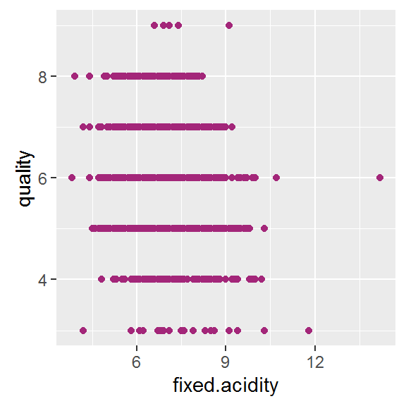

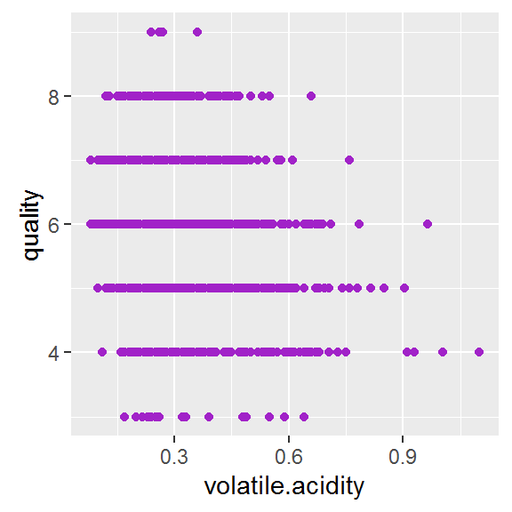

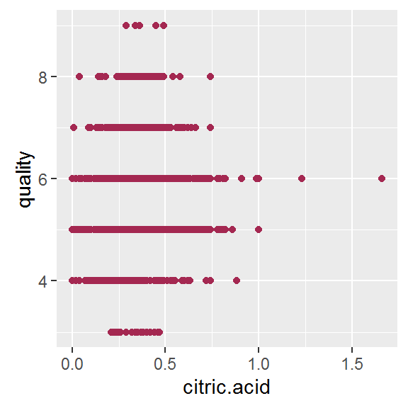

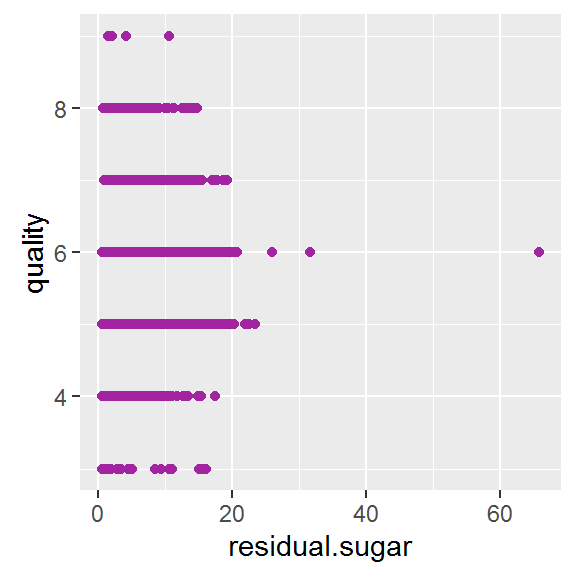

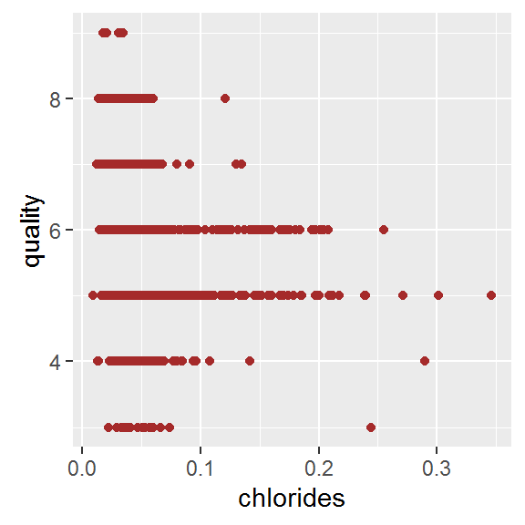

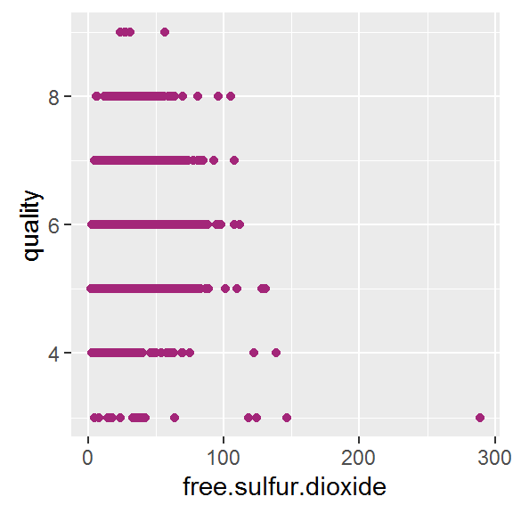

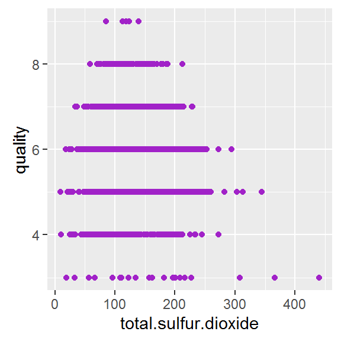

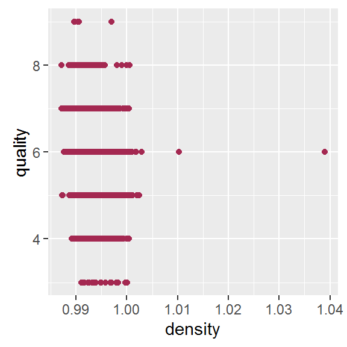

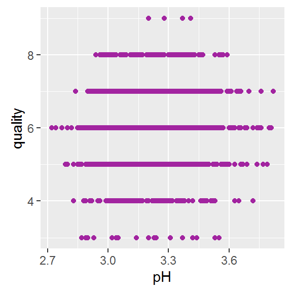

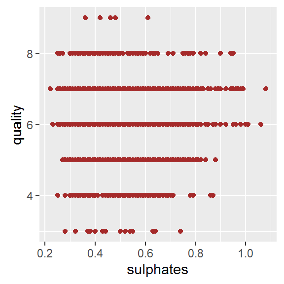

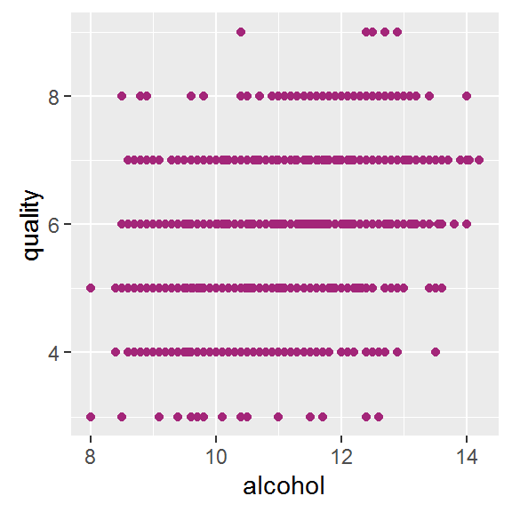

```r
numvars = ncol(df_white)-1
mypal <- colorRampPalette( c( "brown", "purple" ) )( numvars )

for(i in c(1:numvars)   )
{
  print(ggplot( data = df_white, aes(x = df_white[[i]], y=df_white$quality) ) + geom_point(color = mypal[[ (4*i)%%(numvars-1) + 1  ]] ) + labs(x = colnames(df_white)[[i]], y = "quality" ))
}
```

**Linear model training**

Use caret to train a linear model to predict wine quality. First create training and test sets:

```r
inTraining <- createDataPartition(df_white$quality, p = .75, list = FALSE)
training <- df_white[ inTraining,]
testing  <- df_white[-inTraining,]
```

Then use caret to train an optimal linear model:

```r
fitControl <- trainControl(method = "cv", number = 3)
glmFit1 = train(quality ~ ., data = training, method = "glmnet",  trControl = fitControl)
predicted_linear_quality = predict(glmFit1, dplyr::select(testing,-quality) )
df_linear_fit = data.frame(testing$quality, predicted_linear_quality )
```

Plot the linear fit - predicted vs actual:

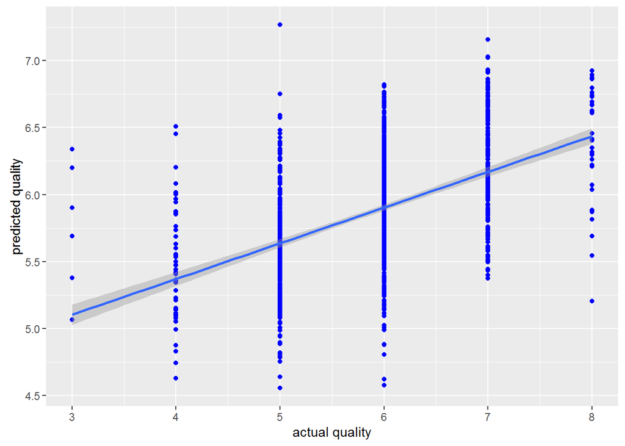

```r
ggplot( data = df_linear_fit, aes(x = testing.quality, y=predicted_linear_quality) ) + geom_point(color = "blue" ) + labs(x = "actual quality", y = "predicted quality" ) + geom_smooth(method = "lm")
```

Finally find the RMSE for the linear model:

```r
RMSE(testing$quality, df_linear_fit$predicted_linear_quality )
```

```
## [1] 0.7635176
```

Examine the coefficients of the best model:

```r
coef(glmFit1$finalModel, s = glmFit1$bestTune$lambda )
```

```
## 12 x 1 sparse Matrix of class "dgCMatrix"
##                                  1
## (Intercept)           1.067070e+02
## fixed.acidity         3.338998e-02
## volatile.acidity     -1.805175e+00
## citric.acid           2.597276e-02
## residual.sugar        6.594062e-02
## chlorides            -3.901717e-01
## free.sulfur.dioxide   2.977486e-03
## total.sulfur.dioxide -5.939087e-04
## density              -1.060735e+02
## pH                    5.145089e-01
## sulphates             4.631626e-01
## alcohol               2.455416e-01
```

*Nonlinear modelling* **K-neasest neighbours**

Next, we will use K-Nearest Neighbors to try to predict the wine quality.

```r
KNN_fit = train(quality ~ ., data = training, method = "kknn", tuneLength=10)
predicted_KNN_quality = predict(KNN_fit, dplyr::select(testing,-quality) )
df_KNN_fit = data.frame(testing$quality, predicted_KNN_quality )
head(df_KNN_fit)
```

```
##   testing.quality predicted_KNN_quality
## 1               6              6.171583
## 2               6              5.590252
## 3               6              5.481814
## 4               6              5.781953
## 5               7              6.159132
## 6               6              5.897704
```

plot an actual vs predited fit for K-nearest neighbours:

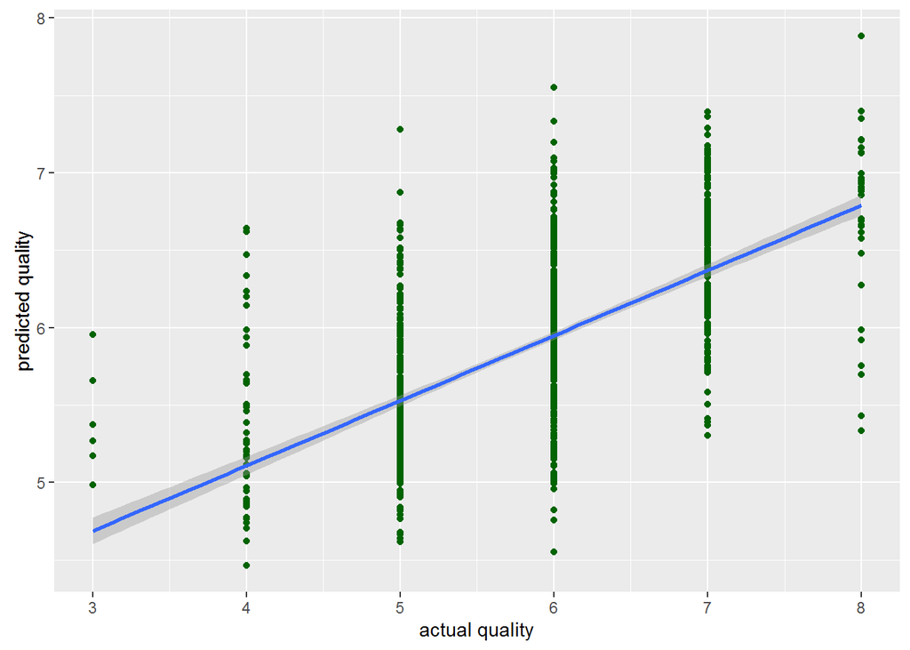

```r
ggplot( data = df_KNN_fit, aes(x = testing.quality, y=predicted_KNN_quality) ) + geom_point(color = "Darkgreen" ) + labs(x = "actual quality", y = "predicted quality" ) + geom_smooth(method = "lm")
```

Find the RMSE for KNN:

```r
RMSE(testing$quality, df_KNN_fit$predicted_KNN_quality)
```

```
## [1] 0.6848762
```

**Regression trees**

Construct a regression tree model to predict white wine quality:

```r
regtree_fit = rpart(quality ~ ., data = training)
```

We can print the tree out:

```r
print(regtree_fit)
```

```
## n= 3674
##
## node), split, n, deviance, yval
##       * denotes terminal node
##
##  1) root 3674 2875.02200 5.881056
##    2) alcohol< 10.85 2311 1372.52000 5.595846
##      4) volatile.acidity>=0.2525 1190  566.63950 5.355462
##        8) free.sulfur.dioxide< 17.5 174   77.79310 4.965517 *
##        9) free.sulfur.dioxide>=17.5 1016  457.85730 5.422244 *
##      5) volatile.acidity< 0.2525 1121  664.12130 5.851026
##       10) volatile.acidity>=0.2075 576  277.58160 5.678819 *
##       11) volatile.acidity< 0.2075 545  351.40550 6.033028
##         22) density< 0.998045 465  257.79780 5.931183 *
##         23) density>=0.998045 80   60.75000 6.625000 *
##    3) alcohol>=10.85 1363  995.77550 6.364637
##      6) alcohol< 11.875 712  525.06600 6.158708
##       12) free.sulfur.dioxide< 11.5 42   40.11905 5.261905 *
##       13) free.sulfur.dioxide>=11.5 670  449.05070 6.214925 *
##      7) alcohol>=11.875 651  407.49310 6.589862 *
```

And we can get predictions for the dataset

```r
predicted_regtree_quality = predict(regtree_fit, dplyr::select(testing,-quality) )
df_regtree_fit = data.frame(testing$quality, predicted_regtree_quality )
head(df_regtree_fit)
```

```
##    testing.quality predicted_regtree_quality
## 3                6                  5.422244
## 4                6                  5.678819
## 8                6                  5.422244
## 9                6                  4.965517
## 14               7                  6.589862
## 25               6                  4.965517
```

Find the RMSE for this regression tree:

```r
RMSE(df_regtree_fit$testing.quality, df_regtree_fit$predicted_regtree_quality )
```

```
## [1] 0.771268
```

Let’s try to train the *cp* hyperparameter using caret’s *train()* function:

```r
tree_caret_fit = train(quality ~ ., data = training, method = "rpart", tuneLength=10)
tree_caret_predictions = predict(tree_caret_fit, dplyr::select(testing,-quality) )
df_tree_caret_fit = data.frame(testing$quality, tree_caret_predictions )
head(df_tree_caret_fit)
```

```
##    testing.quality tree_caret_predictions
## 3                6               5.345367
## 4                6               5.678819
## 8                6               5.345367
## 9                6               4.965517
## 14               7               6.589862
## 25               6               4.965517
```

Find the RMSE for the tree with the best *cp* value:

```r
RMSE(df_tree_caret_fit$testing.quality, df_tree_caret_fit$tree_caret_predictions )
```

```
## [1] 0.7662925
```

Here we get a value slightly smaller (better) than for a tree without tuning the *cp* value, however worse than for K-nearest neighbours.

**Random Forests**